# R Practice: Data visualization with ggplot2

EWHA-GSIS Computational Social Science Workshop

2022-09-24

You can download cheetsheet for ggplot2! (https://www.rstudio.com/resources/cheatsheets/)

## Example: Gapminder dataset

We will use a subset of the gapminder data (https://www.gapminder.org/data/, https://cran.r-project.org/web/packages/gapminder/README.html). At the website https://www.gapminder.org/data/, you can collect more variables.

### Load the dataset

```r
library(gapminder)
library(dplyr)
library(ggplot2)

head(gapminder) ## format: tibble
```

```
## # A tibble: 6 × 6
##   country     continent  year lifeExp      pop gdpPercap
##   <fct>       <fct>     <int>   <dbl>    <int>     <dbl>
## 1 Afghanistan Asia       1952    28.8  8425333      779.
## 2 Afghanistan Asia       1957    30.3  9240934      821.
## 3 Afghanistan Asia       1962    32.0 10267083      853.
## 4 Afghanistan Asia       1967    34.0 11537966      836.
## 5 Afghanistan Asia       1972    36.1 13079460      740.
## 6 Afghanistan Asia       1977    38.4 14880372      786.
```

```r
str(gapminder)
```

```
## tibble [1,704 × 6] (S3: tbl_df/tbl/data.frame)
##  $ country  : Factor w/ 142 levels "Afghanistan",..: 1 1 1 1 1 1 1 1 1 1 ...
##  $ continent: Factor w/ 5 levels "Africa","Americas",..: 3 3 3 3 3 3 3 3 3 3 ...
##  $ year     : int [1:1704] 1952 1957 1962 1967 1972 1977 1982 1987 1992 1997 ...
##  $ lifeExp  : num [1:1704] 28.8 30.3 32 34 36.1 ...
##  $ pop      : int [1:1704] 8425333 9240934 10267083 11537966 13079460 14880372 12881816 13867957 16317921 22227415 ...
##  $ gdpPercap: num [1:1704] 779 821 853 836 740 ...
```

The variables in the dataset:

- `country`: Country name
- `continent`: Continent
- `year`: Year
- `lifeExp`: Life expectancy at birth, in years
- `pop`: Population
- `gdpPercap`: GDP per capita (US$, inflation-adjusted)

We can extract a subset for year = 2007:

```r
gapminder_2007 = gapminder %>%filter(year =='2007')
head(as.data.frame(gapminder_2007))
```

```
##       country continent year lifeExp      pop  gdpPercap
## 1 Afghanistan      Asia 2007  43.828 31889923   974.5803
## 2     Albania    Europe 2007  76.423  3600523  5937.0295
## 3     Algeria    Africa 2007  72.301 33333216  6223.3675
## 4      Angola    Africa 2007  42.731 12420476  4797.2313
## 5   Argentina  Americas 2007  75.320 40301927 12779.3796
## 6   Australia   Oceania 2007  81.235 20434176 34435.3674
```

```r
dim(gapminder_2007)
```

```
## [1] 142   6
```

> **Question 1**: Plot a bar chart to understand the frequency distribution of countries by continent.

**Hint**: For making bar chart, use `geom_bar()`.

**Answer**:

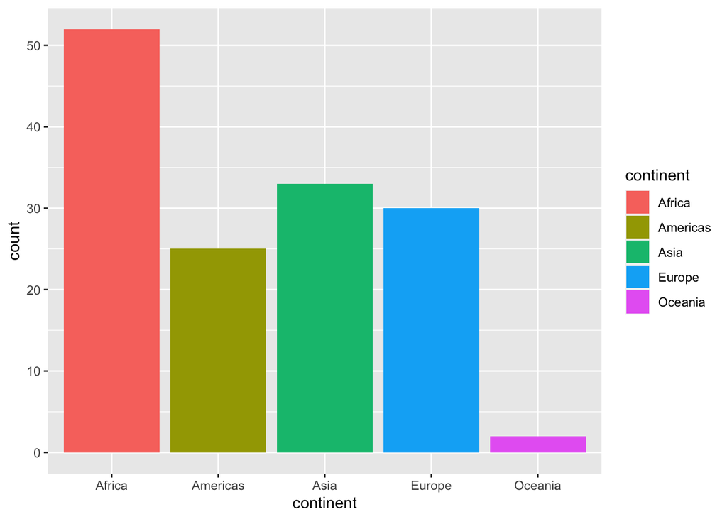

> **Question 2**: How can we visualize the probability distribution of life expectancy by continent?

**Hint**: For continuous variables, a histogram or density plot is useful.

**Answer**:

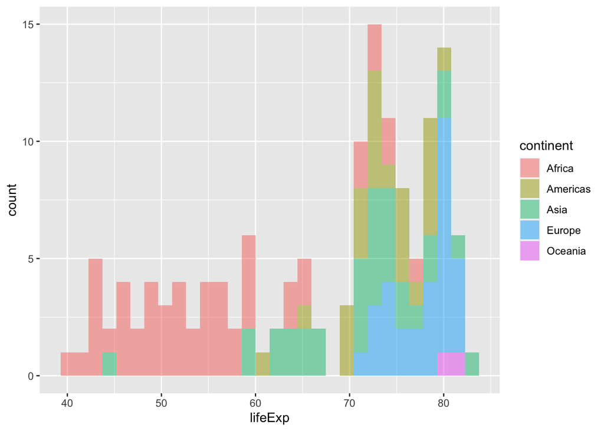

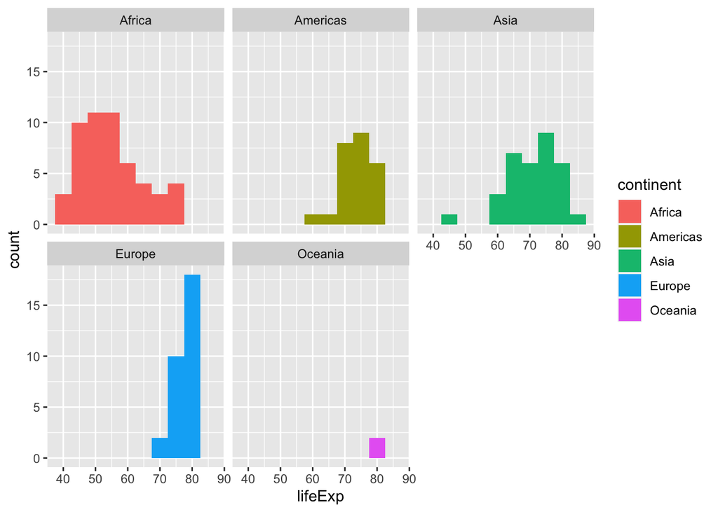

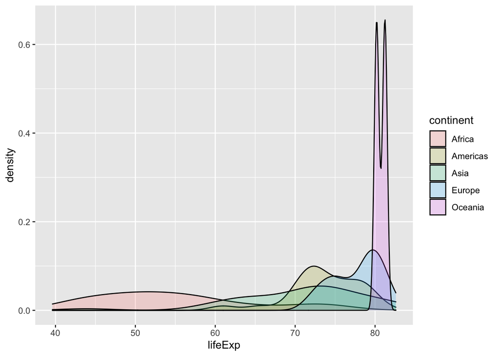

Now, we can extract only European countries from the full data:

```r
europe = gapminder %>%filter(continent =='Europe')
head(as.data.frame(europe))
```

```
##   country continent year lifeExp     pop gdpPercap
## 1 Albania    Europe 1952   55.23 1282697  1601.056
## 2 Albania    Europe 1957   59.28 1476505  1942.284
## 3 Albania    Europe 1962   64.82 1728137  2312.889
## 4 Albania    Europe 1967   66.22 1984060  2760.197
## 5 Albania    Europe 1972   67.69 2263554  3313.422
## 6 Albania    Europe 1977   68.93 2509048  3533.004
```

```r
dim(europe)
```

```
## [1] 360   6
```

> **Question 3**: Plot the boxplot of the Life expentency over time.

**Hint**: Use `geom_boxplot()`

**Answer**:

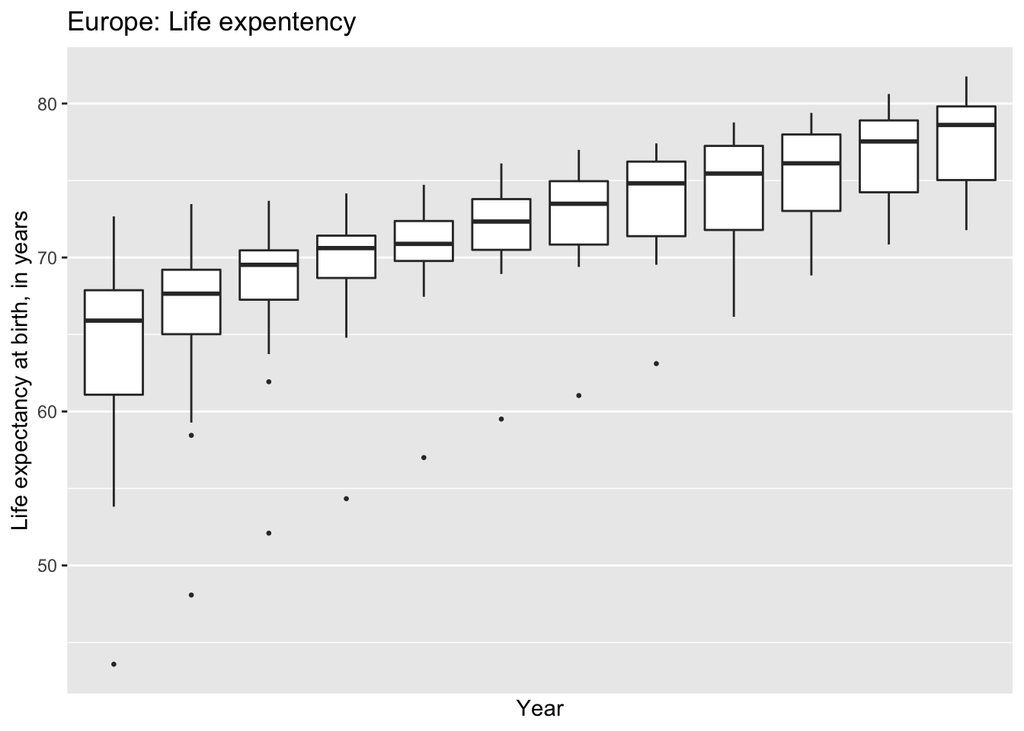

> **Question 4**: We need to investigate the relationship between ‘gdpPercap’ and ‘lifeExp’. Draw the scattor plot (xaxis: ‘gdpPercap’; yaxis:‘lifeExp’).

**Hint**: Use `geom_point`

**Answer**:

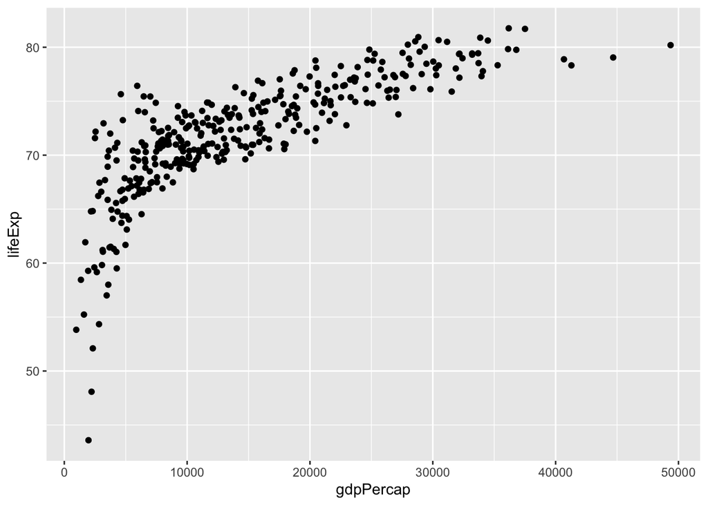

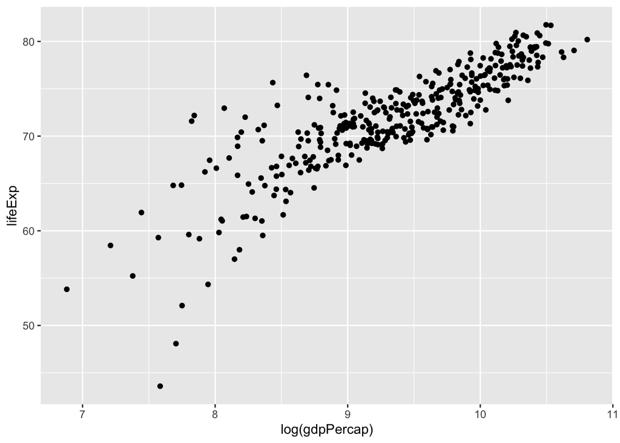

> **Question 5**: For Year = 2007, can we sort the European countries by ‘LifeExp’? Cleveland dot plot is useful.

**Hint**: Use `geom_point`

**Answer**:

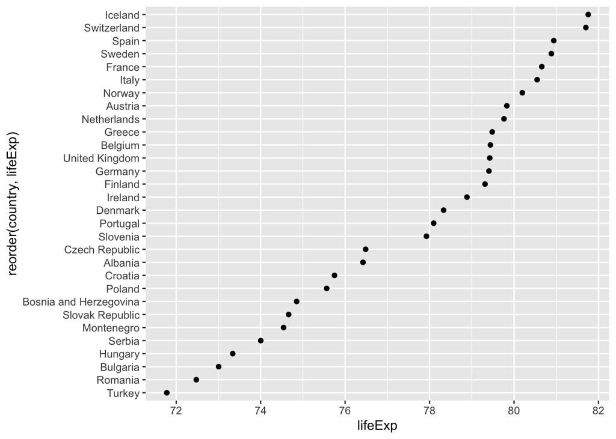

> **Question 6**: Using more detail options, try to draw following fancy figure!

**Hint**: `geom_point`, `scale_size`, `theme_minimal`, `labs` are used.

**Answer**:

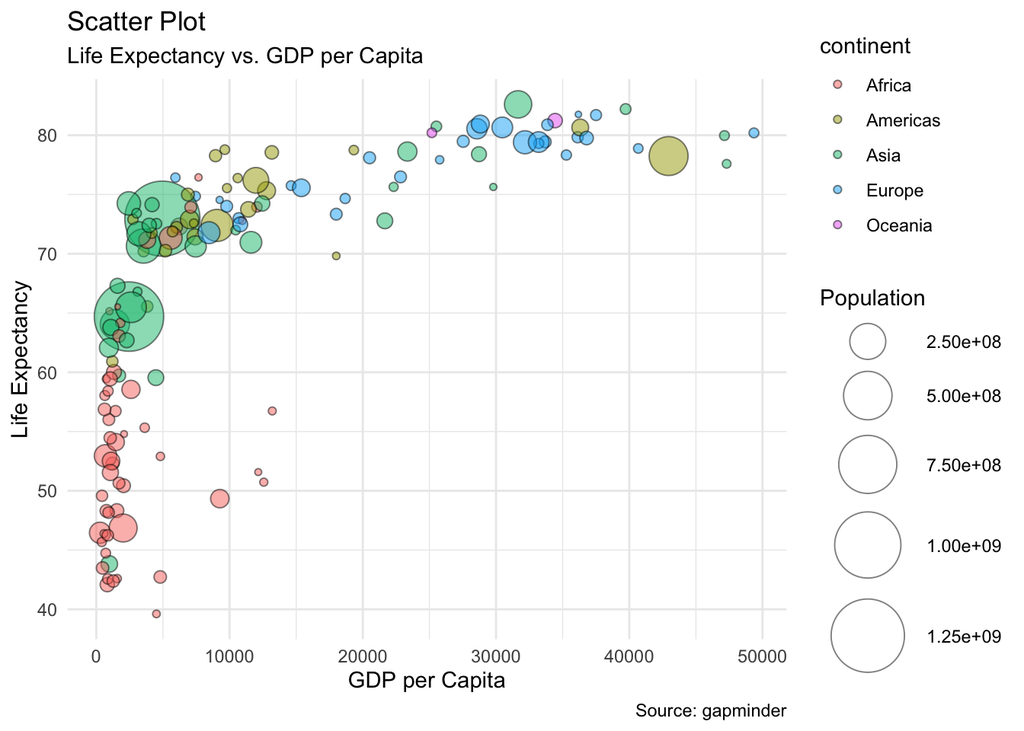

## Example: Bike store sales in Europe

Refer https://www.kaggle.com/datasets/sadiqshah/bike-sales-in-europe?resource=download.

```r
library(tidyverse)
library(ggmosaic)

sales<- read.csv("sales2.csv") # Bike Sales in Europe
head(sales)
```

```
##         Date Day   Month Year Customer_Age            Age_Group Customer_Gender
## 1 2011-01-01   1 January 2011           23          Youth (<25)               M
## 2 2011-01-01   1 January 2011           33 Young Adults (25-34)               F
## 3 2011-01-01   1 January 2011           17          Youth (<25)               M
## 4 2011-01-01   1 January 2011           42       Adults (35-64)               M
## 5 2011-01-01   1 January 2011           39       Adults (35-64)               M
## 6 2011-01-02   2 January 2011           41       Adults (35-64)               F
##         Country            State Product_Category   Sub_Category
## 1     Australia         Victoria            Bikes Mountain Bikes
## 2        France          Yveline            Bikes     Road Bikes
## 3        Canada British Columbia            Bikes     Road Bikes
## 4 United States       California            Bikes     Road Bikes
## 5 United States       Washington            Bikes     Road Bikes
## 6     Australia       Queensland            Bikes     Road Bikes
##                  Product Order_Quantity Unit_Cost Unit_Price Profit Cost
## 1 Mountain-200 Black, 46              1      1252       2295    561 1252
## 2       Road-150 Red, 48              2      2171       3578   1097 4342
## 3       Road-250 Red, 44              1      1519       2443    900 1519
## 4     Road-750 Black, 44              1       344        540    185  344
## 5  Road-550-W Yellow, 38              3       713       1120    482 2139
## 6       Road-250 Red, 58              3      1555       2443   1491 4665
##   Revenue
## 1    1813
## 2    5439
## 3    2419
## 4     529
## 5    2621
## 6    6156
```

```r
dim(sales)
```

```
## [1] 113034     18
```

```r
summary(sales)
```

```
##      Date                Day           Month                Year
##  Length:113034      Min.   : 1.00   Length:113034      Min.   :2011
##  Class :character   1st Qu.: 8.00   Class :character   1st Qu.:2013
##  Mode  :character   Median :16.00   Mode  :character   Median :2014
##                     Mean   :15.67                      Mean   :2014
##                     3rd Qu.:23.00                      3rd Qu.:2016
##                     Max.   :31.00                      Max.   :2016
##   Customer_Age    Age_Group         Customer_Gender      Country
##  Min.   :17.00   Length:113034      Length:113034      Length:113034
##  1st Qu.:28.00   Class :character   Class :character   Class :character
##  Median :35.00   Mode  :character   Mode  :character   Mode  :character
##  Mean   :35.92
##  3rd Qu.:43.00
##  Max.   :87.00
##     State           Product_Category   Sub_Category         Product
##  Length:113034      Length:113034      Length:113034      Length:113034
##  Class :character   Class :character   Class :character   Class :character
##  Mode  :character   Mode  :character   Mode  :character   Mode  :character
##
##
##
##  Order_Quantity   Unit_Cost        Unit_Price         Profit
##  Min.   : 1.0   Min.   :   1.0   Min.   :   2.0   Min.   : -30.0
##  1st Qu.: 2.0   1st Qu.:   2.0   1st Qu.:   5.0   1st Qu.:  29.0
##  Median :10.0   Median :   9.0   Median :  24.0   Median : 101.0
##  Mean   :11.9   Mean   : 267.3   Mean   : 452.9   Mean   : 284.8
##  3rd Qu.:20.0   3rd Qu.:  42.0   3rd Qu.:  70.0   3rd Qu.: 358.0
##  Max.   :32.0   Max.   :2171.0   Max.   :3578.0   Max.   :5638.0
##       Cost           Revenue
##  Min.   :   1.0   Min.   :    2.0
##  1st Qu.:  28.0   1st Qu.:   63.0
##  Median : 108.0   Median :  223.0
##  Mean   : 468.6   Mean   :  753.4
##  3rd Qu.: 432.0   3rd Qu.:  800.0
##  Max.   :8684.0   Max.   :14312.0
```

The variables in the dataset:

- `Date`: Date of the order
- `Day`: Day of the order
- `Month`: Month of the order
- `Year`: Year of the order
- `Customer_Age`: The Age of customer
- `Age_Group`: Age range for the customer
- `Customer_Gender` : The customer gender
- `Country`: The country where the order was made
- `State`: The state where the order was made
- `Product_Category`: Product category for each order
- `Sub_Category`: Product sub category for each order
- `Product`: The product for each order
- `Order_Quantity`: Quantity of the product
- `Unit_Cost`: Cost of inventory holding cost
- `Unit_Price`: The price of the product
- `Profit`: Nett profit of each order
- `Cost`: The sum cost of all product for each order
- `Revenue`: Total revenue of each order

> **Question 7**: How can we visualize the proportion of sales by country and product_category?

**Hint**: use the function `geom_mosaic`.

**Answer**:

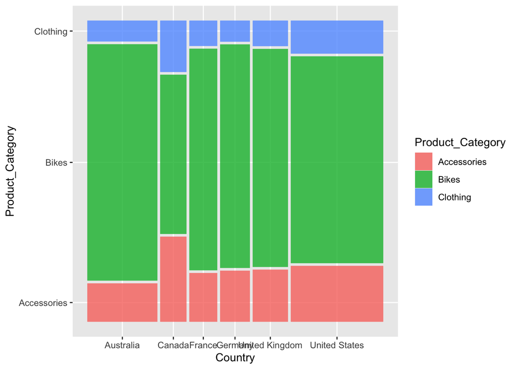

> **Question 8**: Mean comparison: Is there significant differences in the average profit by customer age group?

**Hint**: Use the following the data and the functions `geom_bar`, `geom_errorbar`.

```r
# use aggregate
bike.summary <- aggregate(Profit ~ Age_Group, data = sales, FUN = mean)
bike.sd<-aggregate(Profit ~ Age_Group, data = sales, FUN = sd)[,2]
bike.n<-aggregate(Profit ~ Age_Group, data = sales, FUN = length)[,2]
bike.se<-bike.sd/sqrt(bike.n)

bike.summary$lower<- bike.summary$Profit - 1.96*bike.se
bike.summary$upper<- bike.summary$Profit + 1.96*bike.se

bike.summary
```

```
##              Age_Group   Profit    lower    upper
## 1       Adults (35-64) 291.8640 288.1213 295.6067
## 2        Seniors (64+) 189.2671 164.3812 214.1531
## 3 Young Adults (25-34) 294.5817 290.0069 299.1565
## 4          Youth (<25) 245.3776 239.1107 251.6445
```

**Answer**:

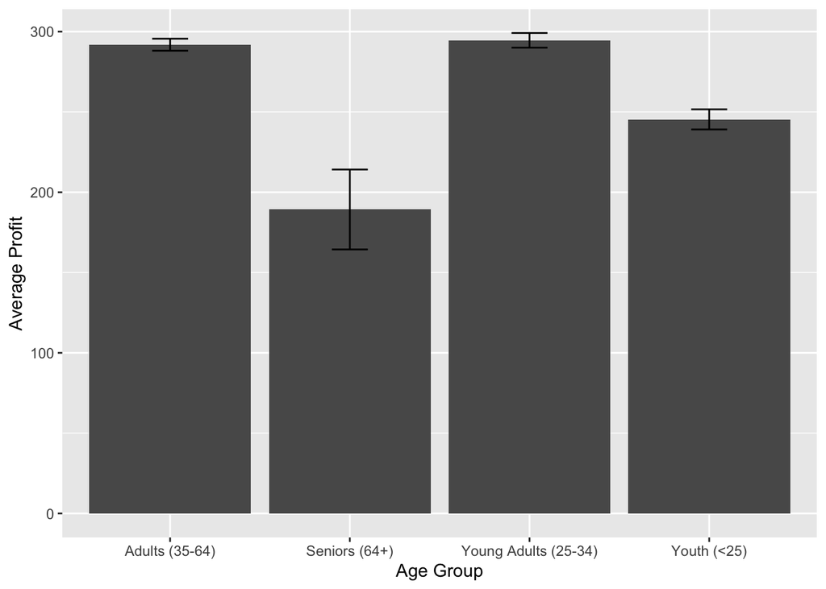

> **Question 9**: How can we check the linear association between cost and profit?

**Hint**: Use the function `geom_smooth`.

**Answer**:

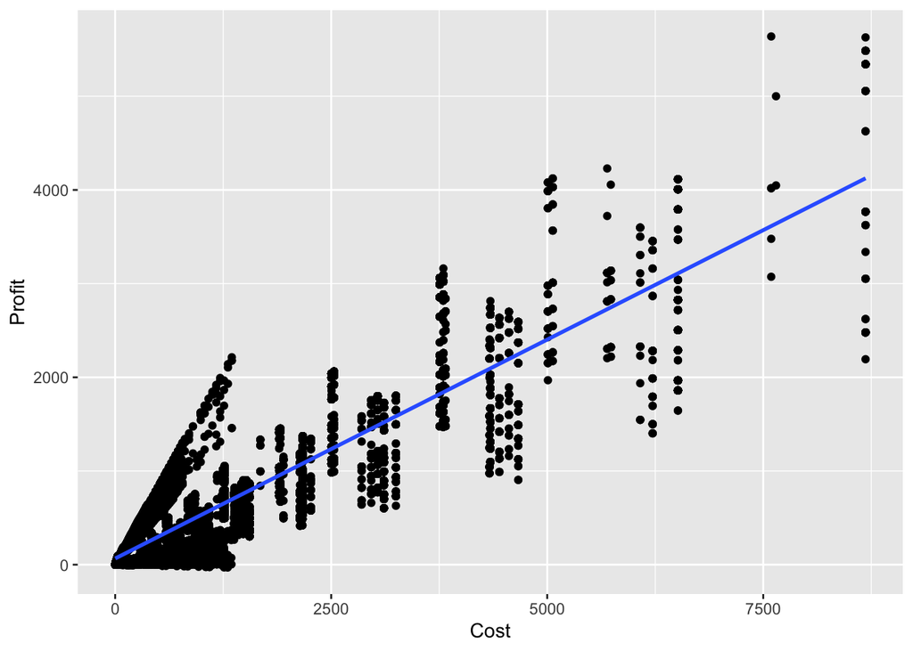

## Word cloud

### Winston Churchill’s Speech (https://www.americanrhetoric.com/speeches/winstonchurchillunitedstatesofeurope.htm)

```r
library(wordcloud)
library(tm)
text<-readLines("Churchill_speech.txt")

# Load the data as a corpus
churchill <- Corpus(VectorSource(text))

inspect(churchill[1:3])
```

```
## <<SimpleCorpus>>
## Metadata:  corpus specific: 1, document level (indexed): 0
## Content:  documents: 3
##
## [1] Mr. President, ladies and gentlemen:
## [2] I am honored today by being received in your ancient university, and by the address which has been given to me on your behalf, and which I greatly value.
## [3] I wish to speak to you today about the tragedy of Europe.
```

```r
# Convert the text to lower case
churchill <- tm_map(churchill, content_transformer(tolower))
# Remove numbers
churchill <- tm_map(churchill, removeNumbers)
# Remove english common stopwords
churchill <- tm_map(churchill, removeWords, c("the","and","will","for","are","that",
                                                "but","and","have","with","from","our",
                                              "there","this","which","must","their"))
# Remove punctuations
churchill <- tm_map(churchill, removePunctuation)
# Eliminate extra white spaces
churchill <- tm_map(churchill, stripWhitespace)


churchill.dtm <- TermDocumentMatrix(churchill)
churchill.mat <- as.matrix(churchill.dtm)
v <- sort(rowSums(churchill.mat),decreasing=TRUE)
d <- data.frame(word = names(v),freq=v)
head(d, 10)
```

```
##            word freq
## europe   europe   20
## all         all   19
## states   states   11
## not         not   11
## nations nations   10
## great     great    9
## united   united    9
## been       been    8
## its         its    8
## would     would    8
```

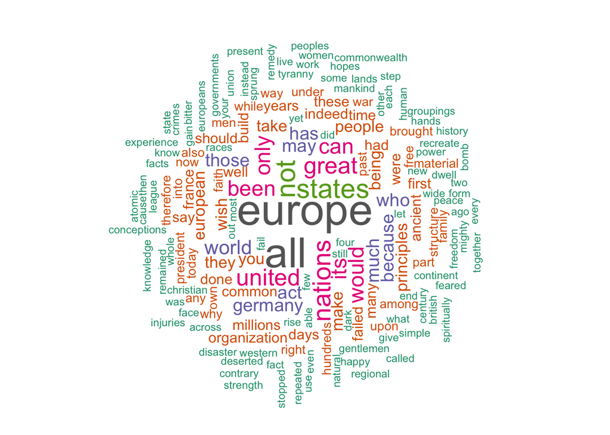

```r
set.seed(1234)
wordcloud(words = d$word, freq = d$freq, min.freq = 2, scale=c(3,0.5),
          max.words=200, random.order=FALSE, rot.per=0.35,
          colors=brewer.pal(8, "Dark2"))
```